# Example R Markdown

Erica Holdridge

2022-09-07

# Main Header

## Set Up Your R Environment

At the beginning of your document, you will want to install/load any necessary packages.

```r
# Install any packages you don't already have.
#install.packages("dplyr")
#install.packages("knitr")
#install.packages("ggplot2")

# Load in the packages you will need.
library(dplyr)
library(knitr)
library(ggplot2)
```

## Formatting Text in R Markdown

You can format text using the following: Create **bold** text or *italic*. This is how you would indicate `code` in the text portion of your file.

R Markdown uses LaTeX to format math equations. Starting a line with `$` tells R to use LaTeX. For example: $A = \pi \times r^{2}$

You can add links using the following syntax: [Class Github](https://github.com/eholdridge2/BIO332)

## Code Chunks

Perhaps the most important feature of an R Markdown file will be the code chunks. Use three backwards apostrophes ``` to indicate a new code chunk:

```r
norm <- rnorm(100, mean = 0, sd = 1)
```

You can also click on the green “+C” button at the top of your R window to add a new code chunk. Notice that R Markdown files can also include code in other programming languages, including Bash and Python.

If you want a code chunk to run and show output without print the code itself, simply add `echo = FALSE` in the beginning of the code chunk:

```
##   A  B
## 1 a  5
## 2 a 10
## 3 b 15
## 4 b 20
```

If you want a code chunk to create an object without printing the code OR the output in the final document, add `include = FALSE`.

Finally, sometimes R packages will produce warnings that aren’t really a problem, but you don’t want them in your final document. In this case, add `warning = FALSE`.

```r
library(dplyr)
```

## Figures and Tables

You can add figures and tables to your R Markdown documents. By default, R Markdown will make figures as tall as possible while still fitting within the side margins of the page. To avoid some really huge figures, you can specify the dimensions you want.

```r
A <- c("a", "a", "b", "b")
B <- c(5, 10, 15, 20)
dataframe <- data.frame(A, B)
print(dataframe)
```

```
##   A  B
## 1 a  5
## 2 a 10
## 3 b 15
## 4 b 20
```

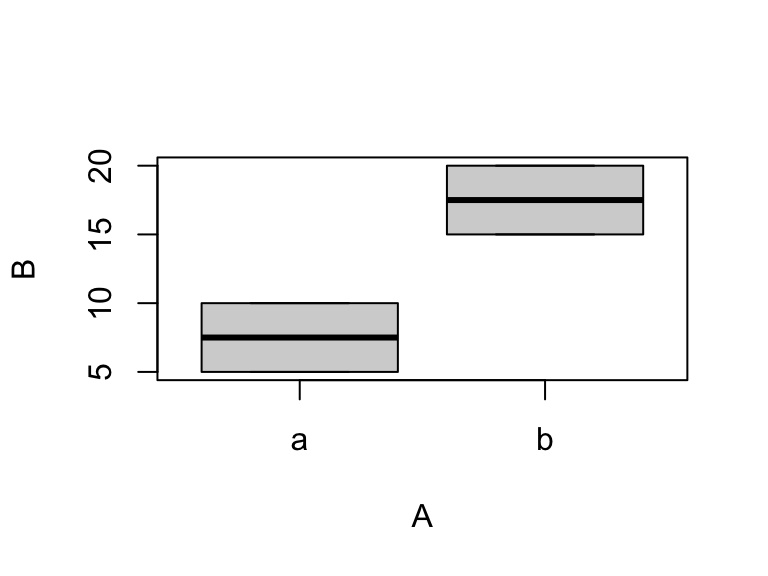

```r
boxplot(B~A,data=dataframe)
```

You can easily print a dataframe by simple writing the name within a code chunk.

```r
dataframe
```

```
##   A  B
## 1 a  5
## 2 a 10
## 3 b 15
## 4 b 20
```

Or, for a more aesthetically pleasing table, use the `kable()` function in the `knitr` package.

```r
library(knitr)
kable(dataframe, digits = 2)
```

| A | B |
| --- | --- |
| a | 5 |
| a | 10 |
| b | 15 |
| b | 20 |

You can also manually create tables outside of code chunks.

| Plant | Temp. | Growth |
| --- | --- | --- |
| A | 20 | 0.65 |
| B | 20 | 0.95 |
| C | 20 | 0.15 |

## Example: